# Nurse Models

2024-08-19

Note: Magnet status is collapsed in the following analyses, such that “I don’t know” values will be treated similarly to “No”s.

# Information Source Use

## Distribution Plots

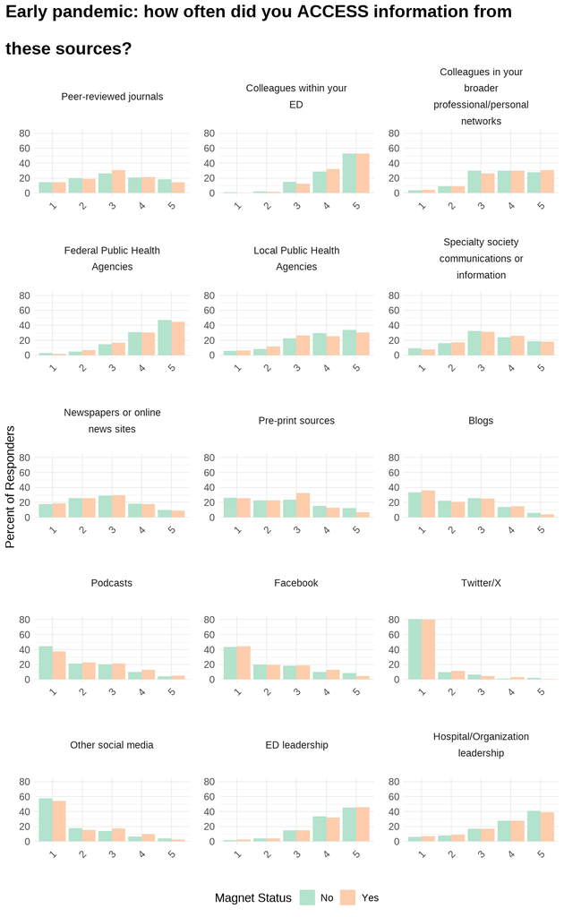

We see no indications of significant differences in use of information sources as a function of Magnet status.

## Summary Boxplots

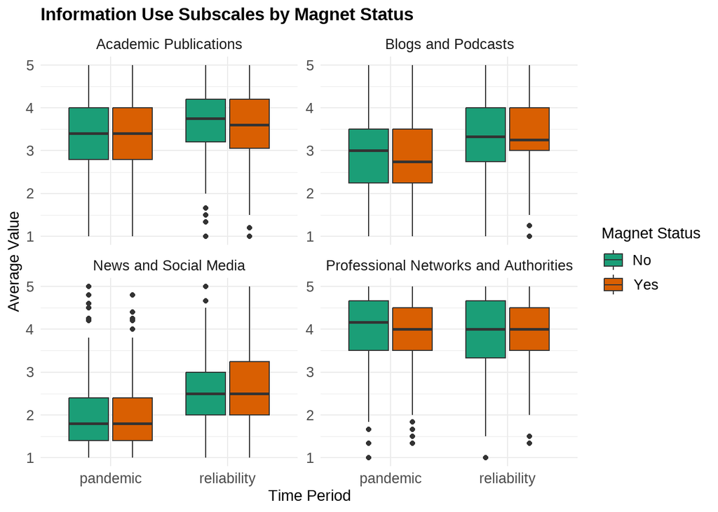

# Organizational Attitudes

## Distribution Plots

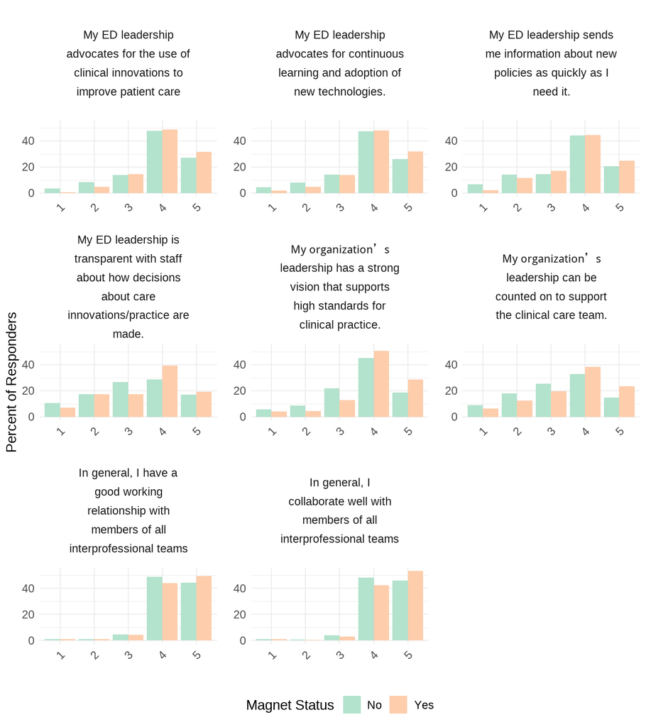

# Adoption Patterns

Here were the patterns of innovation adoption among the sample of 757 nurses:

Innovation Adoption Among Nurses by Magnet Status

Number and percentage of adopters

[output not shown]

# H1: Information Source Use

## H1A: RNs in Magnet hospitals were more likely to report getting information from leadership during the pandemic

The model below tests whether nurses in Magnet hospitals, compared to those at non-Magnet hospitals, relied more on ED leadership (e.g., Department Chair, Nurse Manager) and hospital/organization leadership (e.g., Chief Medical Officer, Chief Nursing Officer) to access information about COVID-19 care innovations in the early pandemic. Items were rated on a 1-5 scale, from “never” to “frequently”. Here, the outcome variable represents the average of these two items.

We also control for age, gender, and perceptions of the leadership sources’ reliability. Here, the variability “scale(age)” indicates a one-SD change, rather than a one-year change, to aid interpretation.

```
##
## Call:
## lm(formula = formula, data = data)
##
## Residuals:
##     Min      1Q  Median      3Q     Max
## -2.3063 -0.5614  0.1137  0.4941  2.8114
##
## Coefficients:
##                                  Estimate Std. Error t value Pr(>|t|)
## (Intercept)                       1.75388    0.14941  11.739  < 2e-16 ***
## magnet_collapsedNo                0.06779    0.06090   1.113  0.26602
## scale(age)                        0.09653    0.02953   3.269  0.00113 **
## gender_collapsedFemale            0.06254    0.07364   0.849  0.39601
## gender_collapsedOther or Unknown  0.07646    0.23070   0.331  0.74042
## leadership_reliability            0.45047    0.02665  16.901  < 2e-16 ***
## ---
## Signif. codes:  0 '***' 0.001 '**' 0.01 '*' 0.05 '.' 0.1 ' ' 1
##
## Residual standard error: 0.7974 on 739 degrees of freedom
##   (12 observations deleted due to missingness)
## Multiple R-squared:  0.2943, Adjusted R-squared:  0.2895
## F-statistic: 61.63 on 5 and 739 DF,  p-value: < 2.2e-16
##
## Significant predictors (p < 0.05):
## (Intercept) : A one-unit change in (Intercept) predicts a increase in leadership_use by 1.754
## 95% Wald CI: [ 1.461 , 2.047 ]
## P-value: 0
##
## scale(age) : A one-unit change in scale(age) predicts a increase in leadership_use by 0.097
## 95% Wald CI: [ 0.039 , 0.154 ]
## P-value: 0.001
##
## leadership_reliability : A one-unit change in leadership_reliability predicts a increase in leadership_use by 0.45
## 95% Wald CI: [ 0.398 , 0.503 ]
## P-value: 0
```

Magnet status does not predict greater use of hospital leadership as an information source. However, perceptions of leadership reliability do.

```
##
## Call:
## lm(formula = leadership_reliability ~ magnet_collapsed, data = df_nurses)
##
## Residuals:
##     Min      1Q  Median      3Q     Max
## -3.9688 -0.8964  0.1036  1.0312  1.1036
##
## Coefficients:
##                    Estimate Std. Error t value Pr(>|t|)
## (Intercept)         4.96875    0.06680  74.378   <2e-16 ***
## magnet_collapsedNo -0.07234    0.08384  -0.863    0.388
## ---
## Signif. codes:  0 '***' 0.001 '**' 0.01 '*' 0.05 '.' 0.1 ' ' 1
##
## Residual standard error: 1.102 on 743 degrees of freedom
##   (12 observations deleted due to missingness)
## Multiple R-squared:  0.001001,   Adjusted R-squared:  -0.0003434
## F-statistic: 0.7446 on 1 and 743 DF,  p-value: 0.3885
```

Nurses at magnet hospitals did not rate their leadership as more reliable than nurses at non-magnet hospitals (p > .05).

However, leaders’ perceived reliability strongly predicted reliance on leadership information.

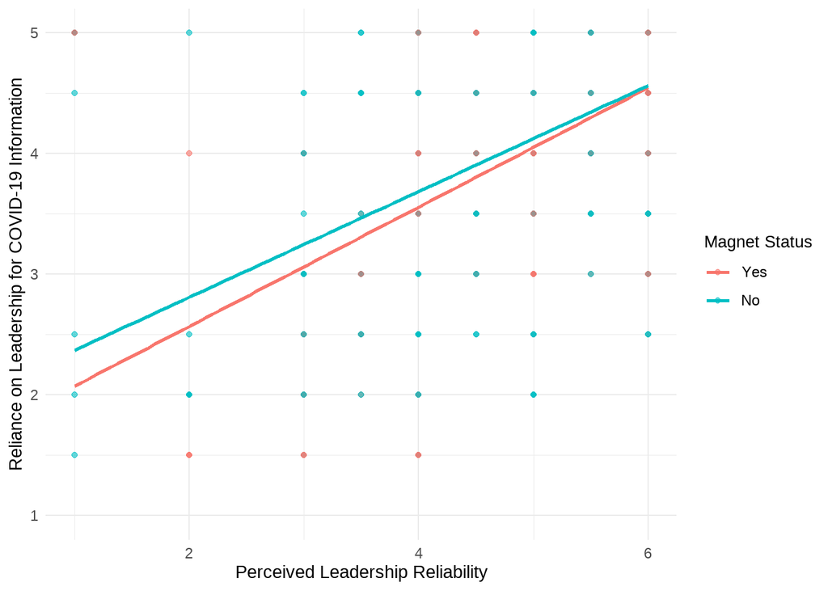

## Exploratory H1B: Do perceptions of organizational practices predict perceptions of leadership reliability?

ED innovation and organizational leadership scores independently predicted perceptions of leadership reliability, though these constructs are moderately correlated, as denoted by the correlation table at the bottom.

```
##
## Call:
## lm(formula = formula, data = data)
##
## Residuals:
##     Min      1Q  Median      3Q     Max
## -4.5662 -0.5773  0.1251  0.7770  2.2043
##
## Coefficients:
##                                  Estimate Std. Error t value Pr(>|t|)
## (Intercept)                       3.27272    0.27719  11.807  < 2e-16 ***
## ed_transpar_avg                   0.00289    0.05677   0.051   0.9594
## ed_innov_avg                      0.14368    0.06946   2.068   0.0389 *
## org_collab_avg                    0.02115    0.06246   0.339   0.7350
## org_lead_avg                      0.24182    0.05358   4.513 7.42e-06 ***
## scale(age)                        0.04302    0.03859   1.115   0.2653
## gender_collapsedFemale            0.14944    0.09602   1.556   0.1200
## gender_collapsedOther or Unknown  0.09130    0.30107   0.303   0.7618
## ---
## Signif. codes:  0 '***' 0.001 '**' 0.01 '*' 0.05 '.' 0.1 ' ' 1
##
## Residual standard error: 1.041 on 737 degrees of freedom
##   (12 observations deleted due to missingness)
## Multiple R-squared:  0.1157, Adjusted R-squared:  0.1074
## F-statistic: 13.78 on 7 and 737 DF,  p-value: < 2.2e-16
##
## Significant predictors (p < 0.05):
## (Intercept) : A one-unit change in (Intercept) predicts a increase in leadership_reliability by 3.273
## 95% Wald CI: [ 2.729 , 3.816 ]
## P-value: 0
##
## ed_innov_avg : A one-unit change in ed_innov_avg predicts a increase in leadership_reliability by 0.144
## 95% Wald CI: [ 0.008 , 0.28 ]
## P-value: 0.039
##
## org_lead_avg : A one-unit change in org_lead_avg predicts a increase in leadership_reliability by 0.242
## 95% Wald CI: [ 0.137 , 0.347 ]
## P-value: 0
```

```
##                 ed_transpar_avg ed_innov_avg org_collab_avg org_lead_avg
## ed_transpar_avg       1.0000000    0.7630239      0.3122517    0.6598291
## ed_innov_avg          0.7630239    1.0000000      0.3853805    0.6893931
## org_collab_avg        0.3122517    0.3853805      1.0000000    0.3802753
## org_lead_avg          0.6598291    0.6893931      0.3802753    1.0000000
```

In the following exploratory analysis, I test whether items assessing perceptions of organizational leadership shape perceptions of leadership’s reliability as a source of information. These are the specific items tested:

1: My organization’s leadership has a strong vision that supports high standards for clinical practice. 2. My organization’s leadership can be counted on to support the clinical care team.

Perceptions of a strong organizational vision and supportive leadership were positively associated with nurses’ perceptions of leadership reliability.

In turn, perceived reliability predicted nurses’ reliance on leadership sources for information during the early pandemic.

Model fit was acceptable (CFI=.96, RMSEA=.10). The standardized paths (β=.12–.53) suggested meaningful relationships consistent with the hypothesis that leadership practices shape perceptions of leadership, which drive utilization by nurses.

```
## lavaan 0.6-18 ended normally after 1 iteration
##
##   Estimator                                         ML
##   Optimization method                           NLMINB
##   Number of model parameters                         5
##
##                                                   Used       Total
##   Number of observations                           745         757
##
## Model Test User Model:
##
##   Test statistic                                15.910
##   Degrees of freedom                                 2
##   P-value (Chi-square)                           0.000
##
## Model Test Baseline Model:
##
##   Test statistic                               344.620
##   Degrees of freedom                                 5
##   P-value                                        0.000
##
## User Model versus Baseline Model:
##
##   Comparative Fit Index (CFI)                    0.959
##   Tucker-Lewis Index (TLI)                       0.898
##
## Loglikelihood and Information Criteria:
##
##   Loglikelihood user model (H0)              -1979.625
##   Loglikelihood unrestricted model (H1)      -1971.670
##
##   Akaike (AIC)                                3969.250
##   Bayesian (BIC)                              3992.317
##   Sample-size adjusted Bayesian (SABIC)       3976.440
##
## Root Mean Square Error of Approximation:
##
##   RMSEA                                          0.097
##   90 Percent confidence interval - lower         0.056
##   90 Percent confidence interval - upper         0.143
```

[output cut: 16 more lines]

```
##     vision                    0.125    0.057    2.187    0.029    0.125
##     support                   0.209    0.051    4.133    0.000    0.209
##   leadership_use ~
##     ledrshp_rlblty            0.456    0.027   17.118    0.000    0.456
##   Std.all
##
##     0.118
##     0.223
##
##     0.531
##
## Variances:
##                    Estimate  Std.Err  z-value  P(>|z|)   Std.lv  Std.all
##    .ledrshp_rlblty    1.086    0.056   19.300    0.000    1.086    0.896
##    .leadership_use    0.642    0.033   19.300    0.000    0.642    0.718
```

Finally, I confirmed that Magnet status does not contribute to any noticeable changes in fit metrics (CFI, RMSEA, etc.) Magnet designation adds no explanatory value beyond perceived leadership practices.

```
## lavaan 0.6-18 ended normally after 2 iterations
##
##   Estimator                                         ML
##   Optimization method                           NLMINB
##   Number of model parameters                         6
##
##                                                   Used       Total
##   Number of observations                           745         757
##
## Model Test User Model:
##
##   Test statistic                                19.591
##   Degrees of freedom                                 3
##   P-value (Chi-square)                           0.000
##
## Model Test Baseline Model:
##
##   Test statistic                               348.567
##   Degrees of freedom                                 7
##   P-value                                        0.000
##
## User Model versus Baseline Model:
##
##   Comparative Fit Index (CFI)                    0.951
##   Tucker-Lewis Index (TLI)                       0.887
##
## Loglikelihood and Information Criteria:
##
##   Loglikelihood user model (H0)              -1979.492
##   Loglikelihood unrestricted model (H1)      -1969.697
##
##   Akaike (AIC)                                3970.984
##   Bayesian (BIC)                              3998.665
##   Sample-size adjusted Bayesian (SABIC)       3979.613
##
## Root Mean Square Error of Approximation:
##
##   RMSEA                                          0.086
##   90 Percent confidence interval - lower         0.052
##   90 Percent confidence interval - upper         0.124
```

[output cut: 18 more lines]

```
##     magnet_collpsd            0.041    0.080    0.515    0.606    0.041
##   leadership_use ~
##     ledrshp_rlblty            0.456    0.027   17.118    0.000    0.456
##   Std.all
##
##     0.120
##     0.224
##     0.018
##
##     0.531
##
## Variances:
##                    Estimate  Std.Err  z-value  P(>|z|)   Std.lv  Std.all
##    .ledrshp_rlblty    1.086    0.056   19.300    0.000    1.086    0.896
##    .leadership_use    0.642    0.033   19.300    0.000    0.642    0.718
```

Here is a visualization of the path model:

[interactive chart not shown]

# H2: Implementation

## Statistical Considerations

Counts by Magnet Status and PPE Variables

| Magnet Status | Decision to Reuse PPE | Flexibility to Make Decision | Count |
| --- | --- | --- | --- |
| Yes | 0 | 1 | 9 |
| Yes | 0 | 2 | 6 |
| Yes | 0 | 3 | 3 |
| Yes | 1 | 1 | 210 |
| Yes | 1 | 2 | 41 |
| Yes | 1 | 3 | 7 |
| No | 0 | 1 | 15 |
| No | 0 | 2 | 6 |
| No | 0 | 3 | 10 |
| No | 1 | 1 | 353 |
| No | 1 | 2 | 88 |
| No | 1 | 3 | 9 |

## H2A: Among RNs who reused N95s and had either some or total flexibility to do so, the RNs in Magnet hospitals were less likely to use colleagues or anecdotes to shape their decision-making compared to those in non-Magnet hospitals.

```
## What colleagues at my institution were doing:
```

```
##
## Call:
## glm(formula = formula, family = binomial, data = data)
##
## Coefficients:
##                                    Estimate Std. Error z value Pr(>|z|)
## (Intercept)                        0.723535   0.903437   0.801   0.4232
## magnet_collapsedNo                -0.722588   0.361944  -1.996   0.0459 *
## age                               -0.009756   0.016052  -0.608   0.5433
## gender_collapsedFemale            -0.272188   0.447312  -0.608   0.5429
## gender_collapsedOther or Unknown  15.052933 882.743472   0.017   0.9864
## ppe1b3                             0.104135   0.549483   0.190   0.8497
## ---
## Signif. codes:  0 '***' 0.001 '**' 0.01 '*' 0.05 '.' 0.1 ' ' 1
##
## (Dispersion parameter for binomial family taken to be 1)
##
##     Null deviance: 195.96  on 144  degrees of freedom
## Residual deviance: 189.35  on 139  degrees of freedom
## AIC: 201.35
##
## Number of Fisher Scoring iterations: 13
##
## Significant predictors (p < 0.05):
## magnet_collapsedNo : A unit change in magnet_collapsedNo predicts a decrease in the log odds of ppe1c_3 by 0.7225883
## Odds Ratio: 0.485494
## 95% Wald CI for OR: [ 0.2388341 ,  0.9868961 ]
## P-value: 0.04588959
## Percentage change in odds: -51.45 %
```

Nurses at Magnet hospitals (vs. those at non-Magnet hospitals) *were* more likely to use colleagues’ feedback to make decisions about PPE reuse. This effect, notably, is stronger when *not* only considering nurses who reused PPE.

## H2B

```
## What colleagues at other institutions were doing:
```

```
##
## Call:
## glm(formula = formula, family = binomial, data = data)
##
## Coefficients:
##                                    Estimate Std. Error z value Pr(>|z|)
## (Intercept)                        -2.59637    1.17789  -2.204   0.0275 *
## magnet_collapsedNo                 -0.14896    0.44577  -0.334   0.7382
## age                                 0.01262    0.01954   0.646   0.5184
## gender_collapsedFemale              0.84856    0.66222   1.281   0.2001
## gender_collapsedOther or Unknown  -13.45175 1455.39767  -0.009   0.9926
## ppe1b3                             -0.14070    0.68460  -0.206   0.8372
## ---
## Signif. codes:  0 '***' 0.001 '**' 0.01 '*' 0.05 '.' 0.1 ' ' 1
##
## (Dispersion parameter for binomial family taken to be 1)
##
##     Null deviance: 142.30  on 144  degrees of freedom
## Residual deviance: 139.67  on 139  degrees of freedom
## AIC: 151.67
##
## Number of Fisher Scoring iterations: 14
##
## Significant predictors (p < 0.05):
## (Intercept) : A unit change in (Intercept) predicts a decrease in the log odds of ppe1c_4 by 2.596366
## Odds Ratio: 0.07454399
## 95% Wald CI for OR: [ 0.007409576 ,  0.7499493 ]
## P-value: 0.02750627
## Percentage change in odds: -92.55 %
```

## H2C

```
## Stories/anecdotes about patient outcomes:
```

```
##
## Call:
## glm(formula = formula, family = binomial, data = data)
##
## Coefficients:
##                                    Estimate Std. Error z value Pr(>|z|)
## (Intercept)                        -1.24196    1.63981  -0.757    0.449
## magnet_collapsedNo                 -0.75143    0.54908  -1.369    0.171
## age                                -0.03488    0.02758  -1.264    0.206
## gender_collapsedFemale              1.07767    1.07631   1.001    0.317
## gender_collapsedOther or Unknown  -11.82884 1455.39793  -0.008    0.994
## ppe1b3                              0.99835    0.67075   1.488    0.137
##
## (Dispersion parameter for binomial family taken to be 1)
##
##     Null deviance: 100.698  on 144  degrees of freedom
## Residual deviance:  92.245  on 139  degrees of freedom
## AIC: 104.24
##
## Number of Fisher Scoring iterations: 14
##
## No significant predictors found.
```

## Corrected Estimates

Here are the H2 estimates corrected for multiple comparisons:

Condensed H2 Model Estimates

| model | term | estimate | p.value | pval_adj_holm | sig |
| --- | --- | --- | --- | --- | --- |
| H2A | (Intercept) | 0.724 | 0.423 | 1.000 |  |
| H2A | magnet_collapsedNo | -0.723 | 0.046 | 0.780 |  |
| H2A | age | -0.010 | 0.543 | 1.000 |  |
| H2A | gender_collapsedFemale | -0.272 | 0.543 | 1.000 |  |
| H2A | gender_collapsedOther or Unknown | 15.053 | 0.986 | 1.000 |  |
| H2A | ppe1b3 | 0.104 | 0.850 | 1.000 |  |
| H2B | (Intercept) | -2.596 | 0.028 | 0.495 |  |
| H2B | magnet_collapsedNo | -0.149 | 0.738 | 1.000 |  |
| H2B | age | 0.013 | 0.518 | 1.000 |  |
| H2B | gender_collapsedFemale | 0.849 | 0.200 | 1.000 |  |
| H2B | gender_collapsedOther or Unknown | -13.452 | 0.993 | 1.000 |  |
| H2B | ppe1b3 | -0.141 | 0.837 | 1.000 |  |
| H2C | (Intercept) | -1.242 | 0.449 | 1.000 |  |
| H2C | magnet_collapsedNo | -0.751 | 0.171 | 1.000 |  |
| H2C | age | -0.035 | 0.206 | 1.000 |  |
| H2C | gender_collapsedFemale | 1.078 | 0.317 | 1.000 |  |
| H2C | gender_collapsedOther or Unknown | -11.829 | 0.994 | 1.000 |  |
| H2C | ppe1b3 | 0.998 | 0.137 | 1.000 |  |

# H3: Deimplementation

## Statistical Considerations

Before answering this question, it’s important to note that we have yet to analyze *which* innovations were discontinued, so the following results may be difficult to interpret.

Secondly, it’s again important to understand how often anecdotal results were cited as a factor in the decision to discontinue an innovation:

Anecdotal results/outcomes from within your ED

| Magnet Status | Outcome Response | Count |
| --- | --- | --- |
| Yes | 0 | 149 |
| Yes | 1 | 127 |
| No | 0 | 269 |
| No | 1 | 212 |

Anecdotal results/outcomes from colleagues elsewhere

| Magnet Status | Outcome Response | Count |
| --- | --- | --- |
| Yes | 0 | 184 |
| Yes | 1 | 92 |
| No | 0 | 329 |
| No | 1 | 152 |

Anecdotal results/outcomes from online and social media sources

| Magnet Status | Outcome Response | Count |
| --- | --- | --- |
| Yes | 0 | 233 |
| Yes | 1 | 43 |
| No | 0 | 436 |
| No | 1 | 45 |

I will collapse the three items about using anecdotal outcomes to guide de-implementation because there is not a theoretical justification that I am aware of for distinguishing them.

## H3A: RNs in Magnet hospitals were less likely to report that ED COVID-19 care innovations were discontinued due to anecdotal results compared to those in non-Magnet hospitals.

In the following analysis, age is a positive, statistically significant predictor of considering anecdotes when making decisions about de-implementation, but the effect is tiny and not seemingly meaningful. Magnet status is not associated with considering anecdotes.

```
##
## Call:
## glm(formula = formula, family = binomial, data = data)
##
## Coefficients:
##                                  Estimate Std. Error z value Pr(>|z|)
## (Intercept)                      -1.10125    0.37451  -2.940  0.00328 **
## magnet_collapsedNo                0.08204    0.15264   0.537  0.59097
## age                               0.01598    0.00710   2.251  0.02441 *
## gender_collapsedFemale            0.30442    0.18573   1.639  0.10120
## gender_collapsedOther or Unknown  0.81246    0.59571   1.364  0.17261
## ---
## Signif. codes:  0 '***' 0.001 '**' 0.01 '*' 0.05 '.' 0.1 ' ' 1
##
## (Dispersion parameter for binomial family taken to be 1)
##
##     Null deviance: 1047.6  on 756  degrees of freedom
## Residual deviance: 1039.0  on 752  degrees of freedom
## AIC: 1049
##
## Number of Fisher Scoring iterations: 4
##
## Significant predictors (p < 0.05):
## (Intercept) : A unit change in (Intercept) predicts a decrease in the log odds of anecdotal_used_any by 1.101245
## Odds Ratio: 0.3324568
## 95% Wald CI for OR: [ 0.159569 ,  0.6926628 ]
## P-value: 0.003277173
## Percentage change in odds: -66.75 %
##
## age : A unit change in age predicts a increase in the log odds of anecdotal_used_any by 0.01598046
## Odds Ratio: 1.016109
## 95% Wald CI for OR: [ 1.002066 ,  1.030348 ]
## P-value: 0.02440861
## Percentage change in odds: 1.61 %
```